# Simmulation Excercise: The welfare cost of suboptimal financial planning

Applied Economic Analysis 1

- Cristina Gómez Fresno
- Laura Ramaciotti Morales

## 1. Question

¿What are the negative effects on welfare when people make their consumption decisions without full knowledge of their preferences?

## 2. Motivation

Pension funds should be governed properly to ensure benefits from decision making with respect to investment and consumption decision at an older age. This is vulnerable when people base their decisions on wrong parameters. In that sense, we evaluate the welfare costs of suboptimal financial planning over the lifecycle, using the benchmark model of Bovenberg, Koijen, Nijman and Teulings (2007) 2.

In the Netherlands the most common form of pension system is the collective one. But currently few individual elements of choice have been introduced. It has been demonstrated that individual choice may be beneficial for people, if individual preferences are known. However, individual choice can make people worse off if people lacks of knowledge. We show how much the welfare loss is when individual preferences are not known.

This study consists in two cases. The first case investigates suboptimal investments decisions as consequence of decision-making based on the wrong parameter of risk aversion ($\theta$). We check how overestimation or underestimation of risk aversion affects the welfare. The second case examines suboptimal investment decisions that result of decision making based on the wrong parameter of time preference ($\rho$). When time preference is higher than the optimal level, we can observe a consumption preference for the near future as opposed to the distant future and vice versa.

## 3. Method

In this section we are going to examine the effects of a misspecification of the optimal risk aversion parameter, $\theta$, and the optimal time preference parameter, $\rho$. The benchmark model of L.Bovenberg, R.Koijen, T.Nijman and C.Teulings 2 is used and the true values for $\theta$ the risk aversion parameter, and $\rho$ the time preference parameter are equal to $\theta=5$ and $\rho=0.02$. The effect on consumption and financial wealth are investigated and compared to the true values.

### Import Libraries needed for our program

```python
import math
import numpy as np
import matplotlib.pyplot as plt
%matplotlib inline
from matplotlib.legend_handler import HandlerLine2D
```

### Specification of model parameters

```python
#Life cycle parameters

D=60 #total time in pension fund
T=45
deltat=1
start_age=20

#Economic parameters
r=0.02 #interest rate
sigma=0.2 #volatility of risky assets
lambda_v= 0.04/sigma


#Specification of Age, Labor Earnings and Human Capital
age=[]
for i in range(1,60,1):
    e=start_age+(i*deltat)
    age.append(e)

def Funcion_Y(i): #Labour earnings
    if age[i-1]<start_age+T:
        return 1
    else:
        return 0

def Funcion_H(i): #Human Capital
        e=(1/r)*(1-math.exp(-r*max(0,(start_age+T-age[i-1]))))
        return e

def Funcion_A(theta, rho):
    w=((1-theta)*r-rho)/theta+0.5*((1-theta)/theta**2)*lambda_v**2
    return w

def Funcion_g(i, theta, rho):
    e=(1/Funcion_A(theta, rho))*(math.exp(Funcion_A(theta, rho)*(D-(age[i-1]-start_age)))-1)
    return e

#Adding extra g, needed for certainty equivalence
def Funcion_g_ce(theta, rho):
    e=(1/Funcion_A(theta, rho))*(math.exp(Funcion_A(theta, rho)*D)-1)
    return e
```

### Defining the paths of consumption, wealth and portfolio choices

The following functions define the dynamics of consumption, financial wealth and portfolio choices. These paths depend on the previously defined parameters and are found using recursive function calls, which are defined according to the appendix of L.Bovenberg, R.Koijen, T.Nijman and C.Teulings 2.

```python
def Funcion_F(n,theta,rho): #Financial Wealth
    if n==1:
        return 0
    else:
        for n in range(2,60,1):
            e=Funcion_F(n-1,theta,rho)+Funcion_F(n-1,theta,rho)*r*deltat+Funcion_fstar_times_F(n-1,theta,rho)*sigma*lambda_v*deltat+Funcion_fstar_times_F(n-1,theta,rho)*math.sqrt(deltat)*sigma*np.random.randn()+(Funcion_Y(n-1)-Funcion_C(n-1,theta,rho))*deltat
            Matrix=np.ones(50000)
            MatrixF=Matrix*e
            w=sum(MatrixF)/len(MatrixF)
            return w

def Funcion_C(n,theta,rho): #Consumption
    for n in range(1,60,1):
        e=(Funcion_F(n,theta,rho)+Funcion_H(n))*Funcion_g(n,theta,rho)**(-1)
        return e

def Funcion_fstar_times_F(n,theta,rho):
    for n in range(1,60,1):
        e=(1/theta)*(lambda_v/sigma)*(Funcion_F(n,theta,rho)+Funcion_H(n))
        return e

def Funcion_fstar(n,theta,rho): #Portfolio choice (percentage of wealth invested in risky assets)
    if n==1:
        return float('nan')
    else:
        for n in range(2,60,1):
            e=Funcion_fstar_times_F(n,theta,rho)/Funcion_F(n,theta,rho)
            return e
```

Regardless of these recursive calls, we have computed the values for each period using Excel, because our Python code was not able to process all the equations simultaneously. The next program imports the outcomes for Financial Wealth, Consumption and Portfolio Choices under each possible scenario, with values $0.01 \leq \rho \leq 0.05$ and $2 \leq \theta \leq 10$.

```python
import xlrd
book = xlrd.open_workbook('/Users/lauraramaciotti/Documents/TILBURG/Economic Analysis/Vectors.xlsx')
sheet = book.sheet_by_name('Sheet1')

#Financial wealth
Ft5r1 = [[sheet.cell_value(r, 0)] for r in range(sheet.nrows)]
Ft5r2 = [[sheet.cell_value(r, 1)] for r in range(sheet.nrows)]
Ft5r3 = [[sheet.cell_value(r, 2)] for r in range(sheet.nrows)]
Ft5r4 = [[sheet.cell_value(r, 3)] for r in range(sheet.nrows)]
Ft5r5 = [[sheet.cell_value(r, 4)] for r in range(sheet.nrows)]

Ft2r2 = [[sheet.cell_value(r, 5)] for r in range(sheet.nrows)]
Ft3r2 = [[sheet.cell_value(r, 6)] for r in range(sheet.nrows)]
Ft4r2 = [[sheet.cell_value(r, 7)] for r in range(sheet.nrows)]
Ft6r2 = [[sheet.cell_value(r, 8)] for r in range(sheet.nrows)]
Ft7r2 = [[sheet.cell_value(r, 9)] for r in range(sheet.nrows)]
Ft8r2 = [[sheet.cell_value(r, 10)] for r in range(sheet.nrows)]
Ft9r2 = [[sheet.cell_value(r, 11)] for r in range(sheet.nrows)]
Ft10r2 = [[sheet.cell_value(r, 12)] for r in range(sheet.nrows)]

#Consumption
Ct5r1 = [[sheet.cell_value(r, 13)] for r in range(sheet.nrows)]
Ct5r2 = [[sheet.cell_value(r, 14)] for r in range(sheet.nrows)]
Ct5r3 = [[sheet.cell_value(r, 15)] for r in range(sheet.nrows)]
Ct5r4 = [[sheet.cell_value(r, 16)] for r in range(sheet.nrows)]
Ct5r5 = [[sheet.cell_value(r, 17)] for r in range(sheet.nrows)]

Ct2r2 = [[sheet.cell_value(r, 18)] for r in range(sheet.nrows)]
Ct3r2 = [[sheet.cell_value(r, 19)] for r in range(sheet.nrows)]
Ct4r2 = [[sheet.cell_value(r, 20)] for r in range(sheet.nrows)]
Ct6r2 = [[sheet.cell_value(r, 21)] for r in range(sheet.nrows)]
Ct7r2 = [[sheet.cell_value(r, 22)] for r in range(sheet.nrows)]
Ct8r2 = [[sheet.cell_value(r, 23)] for r in range(sheet.nrows)]
Ct9r2 = [[sheet.cell_value(r, 24)] for r in range(sheet.nrows)]
Ct10r2 = [[sheet.cell_value(r, 25)] for r in range(sheet.nrows)]

#Portfolio choices
fst5r1 = [[sheet.cell_value(r, 26)] for r in range(sheet.nrows)]
fst5r2 = [[sheet.cell_value(r, 27)] for r in range(sheet.nrows)]
fst5r3 = [[sheet.cell_value(r, 28)] for r in range(sheet.nrows)]
fst5r4 = [[sheet.cell_value(r, 29)] for r in range(sheet.nrows)]
fst5r5 = [[sheet.cell_value(r, 30)] for r in range(sheet.nrows)]

fst2r2 = [[sheet.cell_value(r, 31)] for r in range(sheet.nrows)]
fst3r2 = [[sheet.cell_value(r, 32)] for r in range(sheet.nrows)]
fst4r2 = [[sheet.cell_value(r, 33)] for r in range(sheet.nrows)]
fst6r2 = [[sheet.cell_value(r, 34)] for r in range(sheet.nrows)]
fst7r2 = [[sheet.cell_value(r, 35)] for r in range(sheet.nrows)]
fst8r2 = [[sheet.cell_value(r, 36)] for r in range(sheet.nrows)]
fst9r2 = [[sheet.cell_value(r, 37)] for r in range(sheet.nrows)]
fst10r2 = [[sheet.cell_value(r, 38)] for r in range(sheet.nrows)]
```

## 4. Results

### Suboptimal Investment Decision that Result if Decision Making is based upon the Wrong Parameter of Relative Risk Aversion

#### Effect on consumption

If the average person in the pension fund has a lower risk aversion then the individual has (i.e. $\theta < 5$), the fund will invest more risky than the individual with $\theta = 5$ expects. Then we expect that the consumption will be lower than the average retiree what causes a welfare loss for the individual. The size of the welfare loss will be discussed in **section 5**.

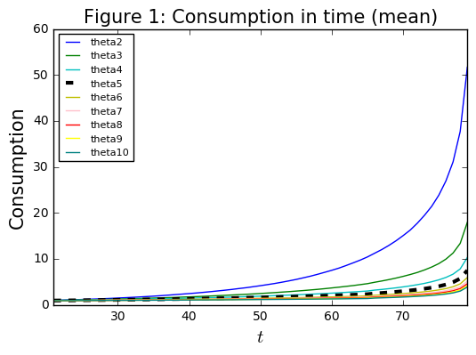

```python
# Effect on Consumption, different values for theta (Relative Risk Aversion)
plt.clf()
plt.plot(age, Ct2r2, '-', color = 'b', linewidth=1, label="theta2")
plt.plot(age, Ct3r2, '-', color = 'g', linewidth=1, label="theta3")
plt.plot(age, Ct4r2, '-', color = 'c', linewidth=1, label="theta4")
plt.plot(age, Ct5r2, '--', color = 'black', linewidth=3, label="theta5")
plt.plot(age, Ct6r2, '-', color = 'y', linewidth=1, label="theta6")
plt.plot(age, Ct7r2, '-', color = 'pink', linewidth=1, label="theta7")
plt.plot(age, Ct8r2, '-', color = 'r', linewidth=1, label="theta8")
plt.plot(age, Ct9r2, '-', color = 'yellow', linewidth=1, label="theta9")
plt.plot(age, Ct10r2, '-', color = 'teal', linewidth=1, label="theta10")
plt.title("Figure 1: Consumption in time (mean)", fontsize=15)
plt.xlabel("$t$", fontsize=15)
plt.ylabel("Consumption", fontsize=15)
plt.xlim(21.0,79)
plt.ylim(0,60)
plt.legend(loc=2, fontsize=8)
```

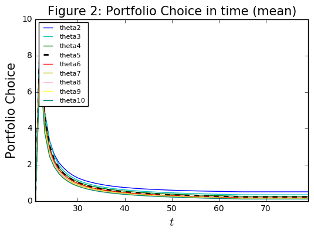

```python
# Portfolio choice, different values for theta
plt.clf()
plt.plot(age, fst2r2, '-', color = 'b', linewidth=1, label="theta2")
plt.plot(age, fst3r2, '-', color = 'c', linewidth=1, label="theta3")
plt.plot(age, fst4r2, '-', color = 'g', linewidth=1, label="theta4")
plt.plot(age, fst5r2, '--', color = 'black', linewidth=2, label="theta5")
plt.plot(age, fst6r2, '-', color = 'r', linewidth=1, label="theta6")
plt.plot(age, fst7r2, '-', color = 'y', linewidth=1, label="theta7")
plt.plot(age, fst8r2, '-', color = 'pink', linewidth=1, label="theta8")
plt.plot(age, fst9r2, '-', color = 'yellow', linewidth=1, label="theta9")
plt.plot(age, fst10r2, '-', color = 'teal', linewidth=1, label="theta10")
plt.title("Figure 2: Portfolio Choice in time (mean)", fontsize=15)
plt.xlabel("$t$", fontsize=15)
plt.ylabel("Portfolio Choice", fontsize=15)
plt.xlim(21.0,79)
plt.legend(loc=2, fontsize=8)
```

#### Effect on financial wealth

We furthermore look at the effect on the mean financial wealth, pictured in **Figure 3**. Here, we see that lower values of $\theta$ are linked to higher financial wealth at retirement age. This, because a less risk averse person is more likely to make riskier investment choices, which will yield a higher profit and higher accumulation of financial wealth. This again can be seen in the higher part in risky assets in **Figure 2**. Furthermore, a lower value of $\theta$ will mean a higher accumulation, and a steeper accumulation trend through time, because the growth rate of assets will also be higher.

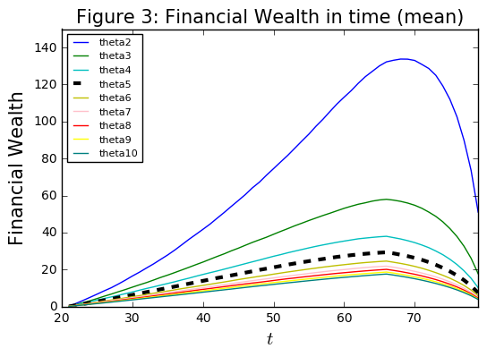

```python
# Financial Wealth, different values for theta
plt.clf()
plt.plot(age, Ft2r2, '-', color = 'b', linewidth=1, label="theta2")
plt.plot(age, Ft3r2, '-', color = 'g', linewidth=1, label="theta3")
plt.plot(age, Ft4r2, '-', color = 'c', linewidth=1, label="theta4")
plt.plot(age, Ft5r2, '--', color = 'black', linewidth=3, label="theta5")
plt.plot(age, Ft6r2, '-', color = 'y', linewidth=1, label="theta6")
plt.plot(age, Ft7r2, '-', color = 'pink', linewidth=1, label="theta7")
plt.plot(age, Ft8r2, '-', color = 'r', linewidth=1, label="theta8")
plt.plot(age, Ft9r2, '-', color = 'yellow', linewidth=1, label="theta9")
plt.plot(age, Ft10r2, '-', color = 'teal', linewidth=1, label="theta10")
plt.title("Figure 3: Financial Wealth in time (mean)", fontsize=15)
plt.xlabel("$t$", fontsize=15)
plt.ylabel("Financial Wealth", fontsize=15)
plt.xlim(20.0,79)
plt.ylim(0,150)
plt.legend(loc=2, fontsize=8)
```

### Suboptimal Investment Decision that Result if Decision Making is based upon the Wrong Parameter of Time Preference

In the previous section we examined the effect of decision making based upon the wrong parameter of risk aversion, in addition we examined the effect of a wrong parameter of time preference ($\rho$). The same aspects are evaluated as in the previous section.

#### Effect on consumption

If a decision is made based on another value of the time preference, we get a suboptimal outcome. The effect on consumption can be found in **Figure 4**.

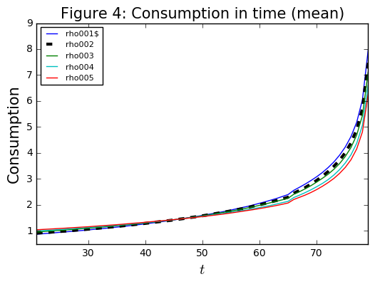

```python
# Consumption, different values for rho
plt.clf()
plt.plot(age, Ct5r1, '-', color = 'b', linewidth=1, label="rho001$")
plt.plot(age, Ct5r2, '--', color = 'black', linewidth=3, label="rho002")
l3=plt.plot(age, Ct5r3, '-', color = 'g', linewidth=1, label="rho003")
l4=plt.plot(age, Ct5r4, '-', color = 'c', linewidth=1, label="rho004")
l5=plt.plot(age, Ct5r5, '-', color = 'r', linewidth=1, label="rho005")
plt.title("Figure 4: Consumption in time (mean)", fontsize=15)
plt.xlabel("$t$", fontsize=15)
plt.ylabel("Consumption", fontsize=15)
plt.xlim(21.0,79)
plt.ylim(0.5,9)
plt.legend(loc=2, fontsize=8)
```

#### Effect on financial wealth

If investments of pension funds where to be made based on a wrong estimation of $\rho$, the accumulation of assets at retirement age would be different than what retirees prefer. I.e., a higher value of $\rho$ would mean that people reach their retirement age with less assets than desired, and a lower value of $\rho$ would result in an accumulation higher than desired.

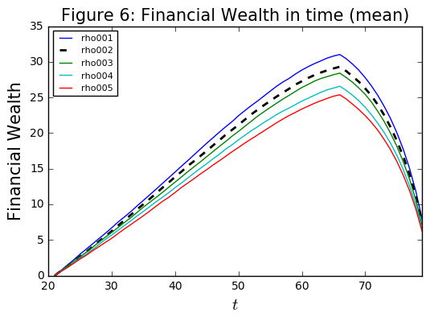

```python
# Financial Wealth, different values for rho
plt.clf()
plt.plot(age, Ft5r1, '-', color = 'b', linewidth=1, label="rho001")
plt.plot(age, Ft5r2, '--', color = 'black', linewidth=2, label="rho002")
plt.plot(age, Ft5r3, '-', color = 'g', linewidth=1, label="rho003")
plt.plot(age, Ft5r4, '-', color = 'c', linewidth=1, label="rho004")
plt.plot(age, Ft5r5, '-', color = 'r', linewidth=1, label="rho005")
plt.title("Figure 6: Financial Wealth in time (mean)", fontsize=15)
plt.xlabel("$t$", fontsize=15)
plt.ylabel("Financial Wealth", fontsize=15)
plt.xlim(20.0,79)
plt.ylim(0,35)
plt.legend(loc=2, fontsize=8)
```

### 5. Welfare Loss due to Wrong Parameter Values

In the current political debate about pensions in the Netherlands choice is an important topic. If choice is offered, participants can gain if their optimal preference parameters are different from the average participant. However the literature shows that participants don’t know their own preferences and that the architectural design of choice can influence the participants. Benartzi and Thaler [1](http://www.anderson.ucla.edu/faculty/shlomo.benartzi/autonomy.pdf) have studied the behavior regarding retirement investments of participants in defined contribution pension schemes. They have found that participants allocate their retirement savings dependent on the portfolio choices offered to them. If this results in a sub-optimal outcome, it may indicate welfare loss on individual level. In order to study the effect of wrong parameter specification, certainty equivalents are computed and compared to the optimal results of the benchmark model by Bovenberg et al. 2. The results are shown in terms of welfare loss.

$$E_t \left( \int_{t}^{D} \frac{e^{-\rho \left( s-t \right)}}{1-\theta} C_s^{1-\theta*}ds \right)=\int_{t}^{D} \frac{e^{-\rho \left( s-t \right)}}{1-\theta} ce_s^{1-\theta}ds$$

The certainty equivalent is computed using the following equation contained in the appendix (A5) of Bovenberg et al. 2.

We computed the certainty equivalents for a consumption-investment policy. The certainty equivalent consumption level $ce$ follows from equation (A27) contained in the appendix of Bovenberg et al. Here $W_0$ is the wealth of the investor at period $0$. For further explanation on parameter $g$ we refer to the appendix of the paper of Bovenberg et al 2.

$$ce=\left(W_0^{1-\theta} g\left(D\right)^\theta \frac{\rho}{1-e^{\rho D}}\right)^{\frac{1}{1-\theta}}$$

We have computed the certainty equivalent for several parameters including the true ones, we can calculate the welfare loss. The welfare loss is equal to:

$$\frac{ce^{true}-ce}{ce}$$

In the last equation, $ce^{true}$ is the certainty equivalent based on the true values of the parameters which are: $\rho=0.02$ and $\theta=5$.

```python
#Creating equation A5

ct5r1=np.array(Ct5r1)
ct5r2=np.array(Ct5r2)
ct5r3=np.array(Ct5r3)
ct5r4=np.array(Ct5r4)
ct5r5=np.array(Ct5r5)

ct2r2=np.array(Ct2r2)
ct2r3=np.array(Ct3r2)
ct2r4=np.array(Ct4r2)
ct2r6=np.array(Ct6r2)
ct2r7=np.array(Ct7r2)
ct2r8=np.array(Ct8r2)
ct2r9=np.array(Ct9r2)
ct2r10=np.array(Ct10r2)

#creating equation A5 for different values of theta and rho
a5_t5r1=[]
a5_t5r2=[]
a5_t5r3=[]
a5_t5r4=[]
a5_t5r5=[]

a5_t2r2=[]
a5_t3r2=[]
a5_t4r2=[]
a5_t6r2=[]
a5_t7r2=[]
a5_t8r2=[]
a5_t9r2=[]
a5_t10r2=[]

for i in range(59):
    e1=(math.exp(-0.01*(age[i]-start_age))*(ct5r1[i])**(1-5))/(1-5)
    e2=(math.exp(-0.02*(age[i]-start_age))*(ct5r1[i])**(1-5))/(1-5)
    e3=(math.exp(-0.03*(age[i]-start_age))*(ct5r1[i])**(1-5))/(1-5)
    e4=(math.exp(-0.04*(age[i]-start_age))*(ct5r1[i])**(1-5))/(1-5)
    e5=(math.exp(-0.05*(age[i]-start_age))*(ct5r1[i])**(1-5))/(1-5)

    e6=(math.exp(-0.02*(age[i]-start_age))*(ct5r1[i])**(1-2))/(1-2)
    e7=(math.exp(-0.02*(age[i]-start_age))*(ct5r1[i])**(1-3))/(1-3)
    e8=(math.exp(-0.02*(age[i]-start_age))*(ct5r1[i])**(1-4))/(1-4)
    e9=(math.exp(-0.02*(age[i]-start_age))*(ct5r1[i])**(1-6))/(1-6)
    e10=(math.exp(-0.02*(age[i]-start_age))*(ct5r1[i])**(1-7))/(1-7)
    e11=(math.exp(-0.02*(age[i]-start_age))*(ct5r1[i])**(1-8))/(1-8)
    e12=(math.exp(-0.02*(age[i]-start_age))*(ct5r1[i])**(1-9))/(1-9)
    e13=(math.exp(-0.02*(age[i]-start_age))*(ct5r1[i])**(1-10))/(1-10)

    a5_t5r1.append(e1)
    a5_t5r2.append(e2)
    a5_t5r3.append(e3)
    a5_t5r4.append(e4)
    a5_t5r5.append(e5)

    a5_t2r2.append(e6)
    a5_t3r2.append(e7)
    a5_t4r2.append(e8)
    a5_t6r2.append(e9)
    a5_t7r2.append(e10)
    a5_t8r2.append(e11)
    a5_t9r2.append(e12)
    a5_t10r2.append(e13)

#Creating expected Utility for different values of theta and rho
Eutilt5r1=sum(a5_t5r1)
Eutilt5r2=sum(a5_t5r2)
Eutilt5r3=sum(a5_t5r3)
Eutilt5r4=sum(a5_t5r4)
Eutilt5r5=sum(a5_t5r5)

Eutilt2r2=sum(a5_t2r2)
Eutilt3r2=sum(a5_t3r2)
Eutilt4r2=sum(a5_t4r2)
Eutilt6r2=sum(a5_t6r2)
Eutilt7r2=sum(a5_t7r2)
Eutilt8r2=sum(a5_t8r2)
Eutilt9r2=sum(a5_t9r2)
Eutilt10r2=sum(a5_t10r2)
```

```python
#Calculating Certainty Equivalent for different values of theta and rho
ce_t5r1=(Eutilt5r1*(1-5)/Funcion_g_ce(5, 0.01))**(1/(1-5))
ce_t5r2=(Eutilt5r2*(1-5)/Funcion_g_ce(5, 0.02))**(1/(1-5))
ce_t5r3=(Eutilt5r3*(1-5)/Funcion_g_ce(5, 0.03))**(1/(1-5))
ce_t5r4=(Eutilt5r4*(1-5)/Funcion_g_ce(5, 0.04))**(1/(1-5))
ce_t5r5=(Eutilt5r5*(1-5)/Funcion_g_ce(5, 0.05))**(1/(1-5))

ce_t2r2=(Eutilt2r2*(1-2)/Funcion_g_ce(2, 0.02))**(1/(1-2))
ce_t3r2=(Eutilt3r2*(1-3)/Funcion_g_ce(3, 0.02))**(1/(1-3))
ce_t4r2=(Eutilt4r2*(1-4)/Funcion_g_ce(4, 0.02))**(1/(1-4))
ce_t6r2=(Eutilt6r2*(1-6)/Funcion_g_ce(6, 0.02))**(1/(1-6))
ce_t7r2=(Eutilt7r2*(1-7)/Funcion_g_ce(7, 0.02))**(1/(1-7))
ce_t8r2=(Eutilt8r2*(1-8)/Funcion_g_ce(8, 0.02))**(1/(1-8))
ce_t9r2=(Eutilt9r2*(1-9)/Funcion_g_ce(9, 0.02))**(1/(1-9))
ce_t10r2=(Eutilt10r2*(1-10)/Funcion_g_ce(10, 0.02))**(1/(1-10))

#Calculating Welfare Loss
WL_t5r1=np.array((ce_t5r2-ce_t5r1)/ce_t5r1)

WL_t5r2=(ce_t5r2-ce_t5r2)/ce_t5r2
WL_t5r3=(ce_t5r2-ce_t5r3)/ce_t5r3
WL_t5r4=(ce_t5r2-ce_t5r4)/ce_t5r4
WL_t5r5=(ce_t5r2-ce_t5r5)/ce_t5r5

WL_t2r2=(ce_t5r2-ce_t2r2)/ce_t2r2
WL_t3r2=(ce_t5r2-ce_t3r2)/ce_t3r2
WL_t4r2=(ce_t5r2-ce_t4r2)/ce_t4r2
WL_t6r2=(ce_t5r2-ce_t6r2)/ce_t6r2
WL_t7r2=(ce_t5r2-ce_t7r2)/ce_t7r2
WL_t8r2=(ce_t5r2-ce_t8r2)/ce_t8r2
WL_t9r2=(ce_t5r2-ce_t9r2)/ce_t9r2
WL_t10r2=(ce_t5r2-ce_t10r2)/ce_t10r2
```

```python
print("theta=5;", "rho 0.01;", "Welfare loss =", WL_t5r1)
print("theta=5;", "rho 0.02;", "Welfare loss =", WL_t5r2)
print("theta=5;", "rho 0.03;", "Welfare loss =", WL_t5r3)
print("theta=5;", "rho 0.04;", "Welfare loss =", WL_t5r4)
print("theta=5;", "rho 0.05;", "Welfare loss =", WL_t5r5)

print("theta=2;", "rho 0.02;", "Welfare loss =", WL_t2r2)
print("theta=3;", "rho 0.02;", "Welfare loss =", WL_t3r2)
print("theta=4;", "rho 0.02;", "Welfare loss =", WL_t4r2)
print("theta=6;", "rho 0.02;", "Welfare loss =", WL_t6r2)
print("theta=7;", "rho 0.02;", "Welfare loss =", WL_t7r2)
print("theta=8;", "rho 0.02;", "Welfare loss =", WL_t8r2)
print("theta=9;", "rho 0.02;", "Welfare loss =", WL_t9r2)
print("theta=10;", "rho 0.02;", "Welfare loss =", WL_t10r2)
```

```
theta=5; rho 0.01; Welfare loss = [ 0.01385282]
theta=5; rho 0.02; Welfare loss = [ 0.]
theta=5; rho 0.03; Welfare loss = [-0.01212231]
theta=5; rho 0.04; Welfare loss = [-0.02277911]
theta=5; rho 0.05; Welfare loss = [-0.03219159]
theta=2; rho 0.02; Welfare loss = [-0.06116542]
theta=3; rho 0.02; Welfare loss = [-0.05270422]
theta=4; rho 0.02; Welfare loss = [-0.02639395]
theta=6; rho 0.02; Welfare loss = [ 0.02362352]
theta=7; rho 0.02; Welfare loss = [ 0.04427592]
theta=8; rho 0.02; Welfare loss = [ 0.06229672]
theta=9; rho 0.02; Welfare loss = [ 0.07809463]
theta=10; rho 0.02; Welfare loss = [ 0.09203608]
```

Results can be found in **Table 1**. Note that the results may vary every time the simulation is done. From the results it follows that as a result of misspecification of a single parameter, that is either $\rho$ or $\theta$, may lead to a welfare loss of up to $9$%. Furthermore it is found that an overestimation of the risk aversion parameter has more welfare loss than an underestimation.

Table 1: Welfare loss due to wrong estimation of parameters

| Welfare Loss | $\rho=0.01$ | $\rho=0.02$ | $\rho=0.03$ | $\rho=0.04$ | $\rho=0.05$ |  |
| --- | --- | --- | --- | --- | --- | --- |
| $\theta=2$ |  | $-0.06$ |  |  |  |  |
| $\theta=3$ |  | $-0.05$ |  |  |  |  |
| $\theta=4$ |  | $-0.02$ |  |  |  |  |
| $\theta=5$ | $0.01$ | $0$ | $-0.01$ | $-0.02$ | $-0.03$ |  |
| $\theta=6$ |  | $0.02$ |  |  |  |  |
| $\theta=7$ |  | $0.04$ |  |  |  |  |
| $\theta=8$ |  | $0.06$ |  |  |  |  |
| $\theta=9$ |  | $0.08$ |  |  |  |  |
| $\theta=10$ |  | $0.09$ |  |  |  |  |

## References

1. Benartzi, Shlomo, and Richard H. Thaler. "How much is investor autonomy worth?." The Journal of Finance 57.4 (2002): 1593-1616.
2. L.Bovenberg, R.Koijen, T.Nijman and C.Teulings. Saving and investing over the life cycle and the role of collective pension funds. July, 2007